# Introduction to Data Visualization

28-Jan-2019

## Motivation

One of the best tools you have to interpreting/understanding your data are your eyes!

A visual representation of your data can reveal patterns and interesting features that would have been difficult or impossible to identify by looking at a data table.

$Graphics + Eyes + Brain = Understanding$

## Motivation

What is the relationship between life expectancy and per capita GDP?

You have 30 seconds to assess the relationship. GO!!

| country | gdpPercap | lifeExp |
| --- | --- | --- |
| Afghanistan | 974.5803 | 43.828 |
| Albania | 5937.0295 | 76.423 |
| Algeria | 6223.3675 | 72.301 |
| Angola | 4797.2313 | 42.731 |
| Argentina | 12779.3796 | 75.320 |
| Australia | 34435.3674 | 81.235 |
| Austria | 36126.4927 | 79.829 |
| Bahrain | 29796.0483 | 75.635 |
| Bangladesh | 1391.2538 | 64.062 |
| Belgium | 33692.6051 | 79.441 |
| Benin | 1441.2849 | 56.728 |
| Bolivia | 3822.1371 | 65.554 |
| Bosnia and Herzegovina | 7446.2988 | 74.852 |
| Botswana | 12569.8518 | 50.728 |
| Brazil | 9065.8008 | 72.390 |
| Bulgaria | 10680.7928 | 73.005 |
| Burkina Faso | 1217.0330 | 52.295 |
| Burundi | 430.0707 | 49.580 |
| Cambodia | 1713.7787 | 59.723 |
| Cameroon | 2042.0952 | 50.430 |
| Canada | 36319.2350 | 80.653 |
| Central African Republic | 706.0165 | 44.741 |
| Chad | 1704.0637 | 50.651 |
| Chile | 13171.6388 | 78.553 |
| China | 4959.1149 | 72.961 |
| Colombia | 7006.5804 | 72.889 |
| Comoros | 986.1479 | 65.152 |
| Congo, Dem. Rep. | 277.5519 | 46.462 |
| Congo, Rep. | 3632.5578 | 55.322 |
| Costa Rica | 9645.0614 | 78.782 |

[output cut: 112 more lines]

## Motivation

What is the relationship between life expectancy and per capita GDP?

You have 30 seconds again…this time it should be much, much easier!

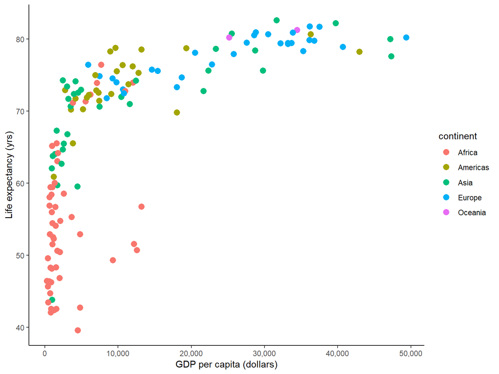

## Motivation

Graphics are critical at all stages of a project – from the initial data aquisition and exploration to the final product that is conveys results to other (colleagues, the public, …).

Graphics reveal patterns and features in data that statistics (*e.g.* mean, median, correlation) may fail to convey/capture.

Consider the four datasets that were constructed by the statistician **Francis Anscombe**

All of four datasets have the following statistics:

| Property |  | Value |
| --- | --- | --- |
| Mean of x |  | 9 |
| Sample variance of x |  | 11 |
| Mean of y |  | 7.5 |
| Sample variance of y |  | 4.125 |
| Corr. between x and y |  | 0.816 |
| Linear regression line |  | y = 3.00 + 0.500x |

Based on the above table you would be led to believe that the data look roughly the same.

## Motivation

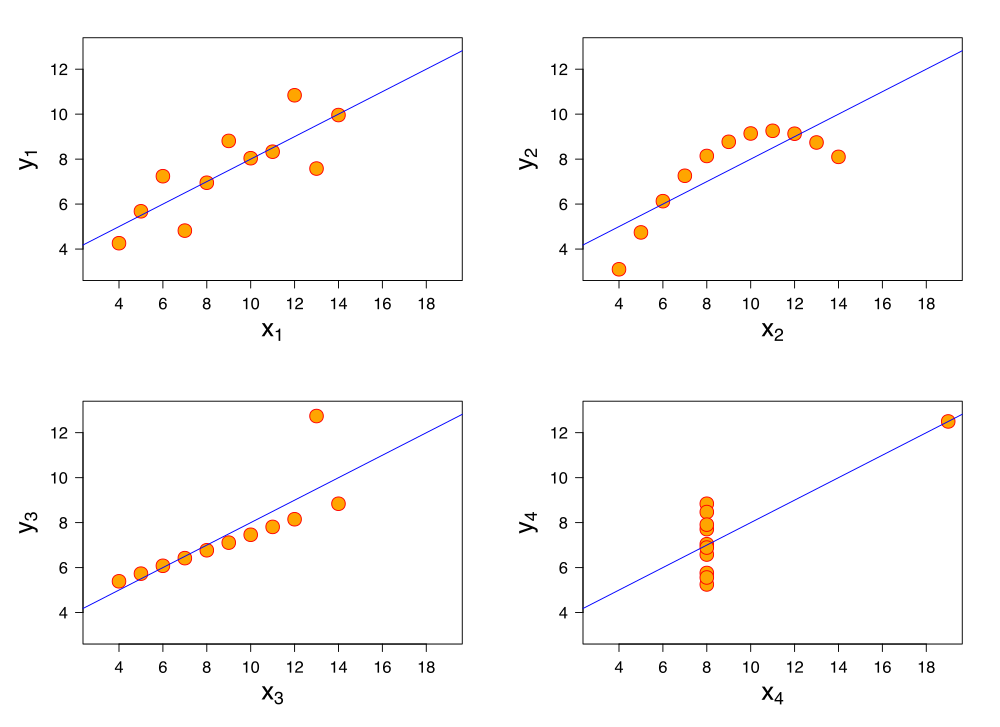

Anscombe’s quartet (source: Wikipedia)

Take home message: You should examine your data graphically!

## Data visualization: Goals

You will create graphics for many different purposes throughout this class and your career.

- When making a graphic you should consider the purpose/goal. Is the graphic for:
  - Exploring and generating initial understanding (**EDA**)
  - Presentation and explanation (*e.g.* conference/thesis presentation, journal article or thesis, …)
  - Engagement (*e.g.* reaching a broader audience via web, video, news,…)

The style, detail, and level of refinement will be a function of your goals.

## Data visualization: EDA

- Exploratory data analysis (EDA):
  - Quickly develop an understanding
  - Inform the next steps of your research
  - Style/formatting/level of polish is not very important

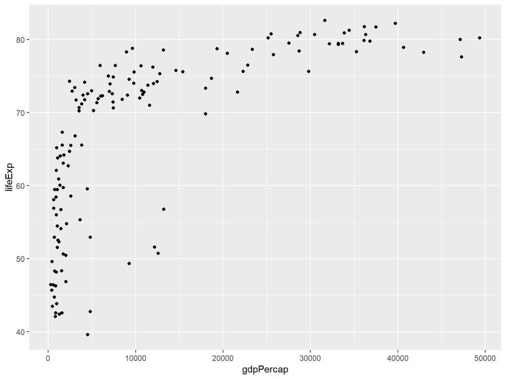

## Data visualization: Presentation quality figures

- Presentation/explanation:
  - Convey and explain findings/results
  - High quality figures

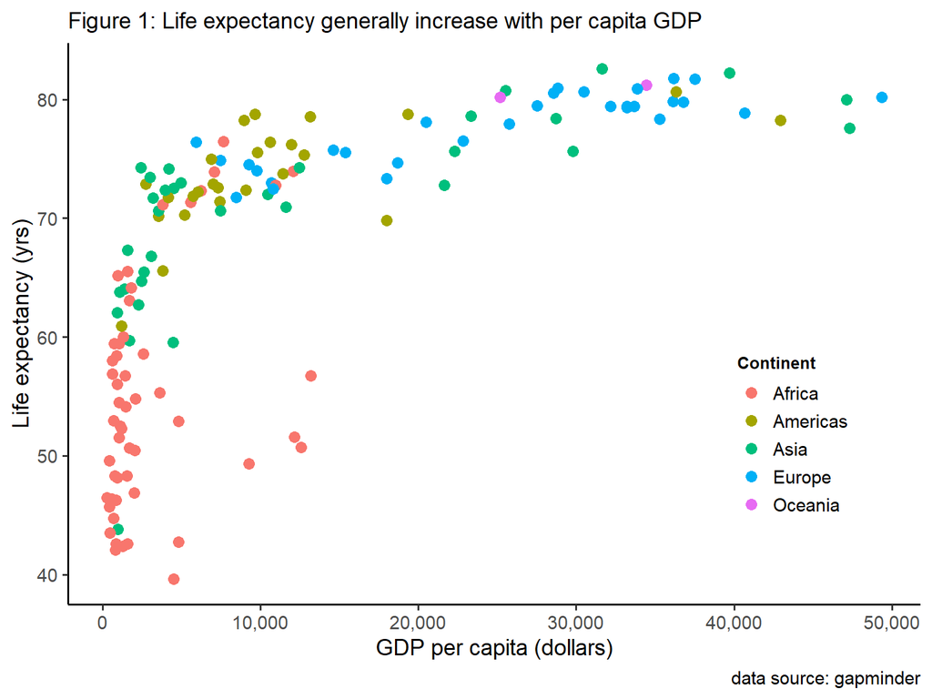

## Data visualization: Engagement

- Engagement of a broader audience
  - Similiar to figures for “presentation”
  - Geared towards a less technical audience
  - May be more stylized and have more “*explanatory*” features

Good examples of these types of figures are found in:

- Popular press (*e.g.* NYTimes, National Geographic, …)
- Many government and NGO websites and publications

## Graphics in `R`

R has excellent graphic making capabilities that allow you to create figures of the highest quality.

In fact many figures you see in scientific journals and in the popular press are made in R (many of the graphics in the NY Times are made in R!).

- The *base graphics* functionality is in the `graphics` package that comes bundled with R.
- There are a number of other graphics packages available for creating graphics in R (*e.g.* `lattice`, `ggplot2` packages)

Most of the figures in this class will be made with the `ggplot2` package.

## Graphics in `R`

In the this and upcoming lectures you will learn how to make static graphics in R.

You will learn fundamental concepts about how to visualize different types of data and how to generate these visualizations in R.

Later in the term we will cover how to make interactive (*dynamic*) graphics and basic maps in R.

## `ggplot2` package

The `ggplot2` package implements what is called the *grammar of graphics*. This is a system that describes a graph’s construction and complex graphs can be built by combining elements together much like you would construct a sentence in a natural language.

- `ggplot2` is widely used (you’ve already been using) and there are countless learning resources freely available.
  - Both of our textbooks, [moderndive](https://moderndive.com/) and [R4DS](https://r4ds.had.co.nz) largely use `ggplot2` to teach data visualizaiton

## `ggplot2` package

*The grammar of graphics* is based on the concept that[^1]:

> A graphic is created by `mapping` the `data` variables to the `aes`thetic attributs of `geom`etric objects.

The three essential components of a graphic are:

1. `data`: dataset containing the mapped variables
2. `geom`: geometric object that the data is mapped to (*e.g.* point, lines, bars, …)
3. `aes`: aesthetic attributes of the geometric object. The aesthetics control how the data variables are mapped to the geometric objects (e.g. x/y position, size, shape, color, …)

Additional components that can be added include:

- **Statistical** elements such as smoothing or binning
- **Facets** for creating mulitiples of graphics based on a categorical variable
- **Coordinate systems** for defining the coordinate system (cartesian, polar, map projection)

## `ggplot2` package

The basic template for creating a graphic in `ggplot2` is

```r
ggplot(data = DATASET) + GEOM_FUNCTION(mapping = aes(MAPPINGS) )
```

- Where:
  - **DATASET** is the name of the data object where your data is stored
  - **GEOM_FUNCTION** is the `geom` function you want to use (*e.g.* `geom_point()`)
  - **MAPPINGS** are the specifications for how you want to map your data to the `geom` (*e.g.* `x = gdpPercap, y = lifeExp, color = continent`)

## Examining graphical components

[figure not shown]

Minard’s illustration of Napolean’s March (source: Wikipedia)

## Examining graphical components

Let’s see how we would construct Minard’s figure using the *grammar of graphics*

| Where? | data variable | aes() | geom_ |
| --- | --- | --- | --- |
| top map | longitude | x | path |
| " | latitude | y | path |
| " | army size | size | path |
| " | army direction (forward vs retreat) | color | path |
| bottom graph | date | x | line and text |
| " | temperature | y | line and text |

[^1]: See md chapter 3.